# Perplexity and Intrinsic Dimensionality

March 20, 2017

## Theory Time

Much of the following discussion is lifted verbatim from the documentation to the fore-runner to `smallvis`, [sneer](http://jlmelville.github.io/sneer/dimensionality.html).

Choosing the correct perplexity value for an embedding is an open research problem. The usual approach is to plump for a value around 30. The [How to Use t-SNE Effectively](http://distill.pub/2016/misread-tsne/) web site demonstrates that multiple perplexity values can give quite different results even for simple synthetic datasets.

Lee and co-workers’ work on [multi-scale neighbor embedding](https://dx.doi.org/10.1016/j.neucom.2014.12.095) attempts to get around this problem by considering multiple perplexities during optimization. Part of their discussion involves making use of the concept of intrinsic dimensionality of the input data and relating that to perplexity.

For estimating the intrinsic dimensionality of the input data, they provide an expression based on one-sided finite differences, which is convenient for multi-scaled neighbor embedding because you calculate the input probabilities for multiple perplexities.

Here I’m going to derive an analytical expression for the dimensionality with the use of the exponential kernel (exponential with regard to the squared distances, or gaussian in the raw distances, if you prefer) that only requires one perplexity calculation.

First, some definitions. This discussion of dimensionality involves the input probabilities, so we will assume the use of gaussian similarities, not anything exotic like the t-distribution or other heavy-tailed functions:

$$w_{ij} = \exp(-\beta_i d_{ij}^{2})$$
where $d_{ij}^{2}$ is the squared distance between point $i$ and $j$ in the input space and $\beta_i$ is the precision (inverse of the bandwidth) associated with point $i$. We use a point-wise normalization to define a probability, $p_{j|i}$:

$$p_{j|i} = \frac{w_{ij}}{\sum_{k} w_{ik}}$$
The Shannon Entropy, $H$, of the probability distribution is:
$$H = -\sum_{j} p_{j|i} \log p_{j|i}$$
and the perplexity, $U$, in units of nats is:

$$U = \exp(H)$$

Lee and co-workers show that, assuming the data is uniformly distributed, the relationship between the precision, perplexity and intrinsic dimensionality around point $i$, $D_i$, is:

$$U \propto \beta_i^{-\left({D_i}/{2}\right)}$$
This suggests that if you did a log-log plot of the perplexity against the precision for multiple perplexities, the graph should be linear and the gradient would be $-D_{i}/2$.

With a multiscaling approach, a finite difference expression using base 2 logarithms is given as:
$$D_i = \frac{2}{\log_2\left(\beta_{U,i}\right)-\log_2\left(\beta_{V,i}\right)}$$

where $\beta_{U,i}$ is the precision parameter for the gaussian function which generates the $i$th similarity/weight for some perplexity, $U$.

### An Analytical Expression for Intrinsic Dimensionality

The following is something I just came up with myself. It’s *not* in the paper by Lee and co-workers, so take it for what it’s worth (probably not much).

The gradient of the log-log plot of the perplexity against the precision is:

$$\frac{\partial \log U}{\partial \log \beta_i} =
\beta_i \frac{\partial H}{\partial \beta_i} =
-\frac{D_{i}}{2}$$
so

$$D_i = -2 \beta_i \frac{\partial H}{\partial \beta_i}$$

We therefore need to find an expression for $\partial H / \partial \beta_{i}$. Fortunately, we can use similar chain rule expressions and nomenclature that I went into in great and tedious detail in the discussion of deriving the SNE gradient.

To start, we can write the derivative as:

$$\frac{\partial H}{\partial \beta_i} =
\sum_{jklm}
\frac{\partial H}{\partial p_{k|j}}
\frac{\partial p_{k|j}}{\partial w_{lm}}
\frac{\partial w_{lm}}{\partial \beta_{i}}$$

$\partial w_{lm} / \partial \beta_{i} = 0$ unless $l = i$. Additionally, due to the point-wise normalization, $\partial p_{k|j} / \partial w_{lm} = 0$ unless $j = l$, allowing us to simplify the summation to:

$$\frac{\partial H}{\partial \beta_i} =
\sum_{km}
\frac{\partial H}{\partial p_{k|i}}
\frac{\partial p_{k|i}}{\partial w_{im}}
\frac{\partial w_{im}}{\partial \beta_{i}}$$
Now let us regroup that double summation into two single summations, and also rename $m$ to $j$:

$$\frac{\partial H}{\partial \beta_i} =
\sum_{j}
\left[
\sum_{k}
\frac{\partial H}{\partial p_{k|i}}
\frac{\partial p_{k|i}}{\partial w_{ij}}
\right]
\frac{\partial w_{ij}}{\partial \beta_{i}}$$
We are now in very familiar territory if you have read the SNE gradient page. The full details of how to derive the expression of the gradient of the weight normalization is on that page, but we shall jump straight to inserting the result for $\partial p_{k|i} / \partial w_{ij}$ to get:

$$\frac{\partial H}{\partial \beta_i} =
\sum_{j}
\frac{1}{S_{i}}
\left[
\frac{\partial H}{\partial p_{j|i}}
-\sum_{k}
\frac{\partial H}{\partial p_{k|i}}
p_{k|i}
\right]
\frac{\partial w_{ij}}{\partial \beta_{i}}$$
where $S_{i}$ is:

$$S_{i} = \sum_{j} w_{ij}$$

The gradient of the Shannon Entropy with respect to the probability is:

$$\frac{\partial H}{\partial p_{j|i}} =
- \log \left( p_{j|i} \right) - 1$$
substituting into the expression in square brackets:

$$\left[
\frac{\partial H}{\partial p_{j|i}}
-\sum_{k}
\frac{\partial H}{\partial p_{k|i}}
p_{k|i}
\right]
=
\left[
- \log \left( p_{j|i} \right) - 1
-\sum_{k}
\left\{
- \log \left( p_{k|i} \right) - 1
\right\}
p_{k|i}
\right]
=
\left[
- \log \left( p_{j|i} \right) - 1
+\sum_{k}
p_{k|i} \log \left( p_{k|i} \right)
+\sum_{k}
p_{k|i}
\right]$$
and because $\sum_k p_{k|i} = 1$, we eventually get to:
$$\left[
\frac{\partial H}{\partial p_{j|i}}
-\sum_{k}
\frac{\partial H}{\partial p_{k|i}}
p_{k|i}
\right]
=
\left[
- \log \left( p_{j|i} \right) - H
\right]
=
-\left[
\log \left( p_{j|i} \right) + H
\right]$$
At this point:

$$\frac{\partial H}{\partial \beta_i} =
\sum_{j}
-\frac{1}{S_{i}}
\frac{\partial w_{ij}}{\partial \beta_{i}}
\left[
\log \left( p_{j|i} \right) + H
\right]$$

which leads to:

$$D_{i} = \frac{2 \beta_i}{S_i}
\sum_{j}
\frac{\partial w_{ij}}{\partial \beta_{i}}
\left[
\log \left( p_{j|i} \right) + H
\right]$$

The gradient of the exponential weight with respect to the precision parameter, $\beta_i$, is:

$$\frac{\partial w_{ij}}{\partial \beta_{i}}
=
-d_{ij}^2 w_{ij}$$

Substituting these two sub expressions into the total gradient, we are left with:
$$\frac{\partial H}{\partial \beta_i} =
\sum_{j}
\frac{d_{ij}^2 w_{ij}}{S_{i}}
\left[
\log \left( p_{j|i} \right) + H
\right]$$

Additionally, $p_{j|i} = w_{ij} / S_{i}$, so the final expression for the gradient is:

$$\frac{\partial H}{\partial \beta_i} =
\sum_{j}
d_{ij}^2 p_{j|i}
\left[
\log \left( p_{j|i} \right) + H
\right]$$

The only thing to left to do is to multiply this expression by $-2 \beta_{i}$ to get this expression for the intrinsic dimensionality:

$$D_i = -2 \beta_i \sum_j d^2_{ij} p_{j|i} \left[\log\left(p_{j|i}\right) + H\right]$$

which is useful if you’ve carried out the perplexity-based calibration on the input weights, as you have already calculated $p_{j|i}$, $H$ and $\beta_i$.

### Un-normalized weights

If you’d rather think in terms of the un-normalized weights and the distances only, the usual expression for Shannon entropy can be rewritten in terms of weights as:

$$H = \log S_{i} -\frac{1}{S_i} \left( \sum_j w_{ij} \log w_{ij} \right)$$

to give:

$$D_{i} = \frac{2 \beta_i}{S_i^2}
\sum_{j}
\frac{\partial w_{ij}}{\partial \beta_{i}}
\left(
S_i \log w_{ij} - \sum_k w_{ik} \log w_{ik}
\right)$$

We can also express the relation between the weight and the squared distance as:

$$\log \left( w_{ij} \right) = -\beta_i d_{ij}^2$$
and the gradient with respect to the precision as:

$$\frac{\partial w_{ij}}{\partial \beta_{i}}
=
-d_{ij}^2 w_{ij} = -\frac{w_{ij} \log w_{ij}}{\beta_i}$$

and the Shannon entropy expression as:

$$H = \log S_i + \frac{\beta_i}{S_i} \sum_j d_{ij}^2 w_{ij}$$

With all that, you can eventually get to two equivalent expressions for $D_i$:

$$D_{i} = \frac{2}{S_i}
\left\{
\sum_j w_{ij} \left[ \log \left( w_{ij} \right) \right] ^ 2
-\frac{1}{S_i} \left[ \sum_j w_{ij} \log \left( w_{ij} \right) \right]^2
\right\}$$
$$D_{i} = \frac{2 \beta_i^2}{S_i}
\left[
\sum_j d_{ij}^4 w_{ij}
-\frac{1}{S_i} \left( \sum_j d_{ij}^2 w_{ij} \right)^2
\right]$$
The first one only requires the $W$ matrix, although as you’ve been carrying out lots of exponential operations to generate the weights, it seems a pity to have to then carry out lots of expensive log calculations, in which case the second expression might be better, but which requires the squared distance matrix and $\beta_i$ also.

## The Maximum Mean Intrinsic Dimensionality Method

Based on the above discussion, it should be possible to calculate the intrinsic dimensionality associated with each point in a dataset, for a given perplexity. To characterize the intrinsic dimensionality of a dataset we can then average the individual values. This can be repeated for multiple perplexities and the maximum mean value of the intrinsic dimensionalities can be taken as the intrisic dimensionality of the dataset. The perplexity associated with the maximum mean intrinsic dimensionality seems like it would be a good choice in t-SNE.

Some datasets have different dimensionalities depending on the length scale ( corresponding to different perplexities), e.g. the Swiss Roll dataset, while three-dimensional, can be considered two-dimensional over short distances.

Or, imagine a dataset containing a 50D Gaussian and 100D Gaussian. Does one intrinsic dimensionality make sense in that case? If not, then that also implies that maybe one perplexity value isn’t always the optimal choice. Perhaps the 50D Gaussian needs a substantially different perplexity to a 100D Gaussian. In that case, we might want to take the point-wise dimensionality estimates, and consider the mean of the points taken from the 50D Gaussian separately from the 100D Gaussian.

[How to Use t-SNE Effectively](https://distill.pub/2016/misread-tsne/) notes that there “may not be one perplexity value that will capture distances across all clusters — and sadly perplexity is a global parameter. Fixing this problem might be an interesting area for future research.” Perhaps intrinsic dimensionality can help here.

## Method

In t-SNE and related methods, we carry out the perplexity calibration once for a fixed perplexity before optimizing the output probabilities to match these calibrated input probabilities.

For investigating intrinsic dimensionality, we will carry out the perplexity calibration multiple times at different perplexity values. We’ll start at a low value (e.g. 3-5) and look at every integer perplexity up to around 300, which should be a large enough value to capture any features of interest. For each perplexity, we’ll record the intrinsic dimensionality of each point and then average those values to get a single intrinsic dimensionality for that perplexity. Plotting the mean intrinsic dimensionality against perplexity should hopefully reveal interesting structure or at least an obvious maximum.

Alternatively, rather than calculate a single dimensionality, we can take the average over point associated with a particular cluster or category in a class. For instance, for the `mnist` dataset, we can average the dimensionality for all the 1s, separately from the 2s, 3s, 4s and so on, to give both a whole dataset intrinsic dimensionality and 10 separate dimensionalities, one for each digit class. After all, we wouldn’t necessarily expect each digit to be distributed across a digit-manifold in the same way.

Obviously, doing loads of perplexity calibrations is slow, and the time taken increases with the square of the dataset, so carrying out hundreds of calibrations on a large dataset (`mnist` or `fashion` for examples) is not something you want to do more than once, and couldn’t be integrated into standard t-SNE. A simpler approach that isn’t such a computational burden is suggested in the section “A Practical Suggestion for Perplexity Selecton”.

## Synthetic Data

Both “How to Use t-SNE Effectively” and the multiscale JSE paper used synthetic data to explore perplexity and intrinsic dimensionality, respectively, so we shall also start with some simple synthetic data which will hopefuly provide some clear trends and patterns, before we look at real data, which inevitably destroys all our hopes and dreams with its annoying messiness and real-ness.

### 2D, 5D, 10D Gaussian

An obvious place to start is with some simple Gaussians. We’ll look at the effect of increasing dimensionality, and also of the effect of increasing the amount of data available to us, although even with these datasets, I don’t look at more than 3,000 points, due to the amount of time it takes to generate plots for larger datasets.

```
g2d_1k <- snedata::gaussian_data(n = 1000, dim = 2)
g5d_1k <- snedata::gaussian_data(n = 1000, dim = 5)
g10d_1k <- snedata::gaussian_data(n = 1000, dim = 10)

g2d_3k <- snedata::gaussian_data(n = 3000, dim = 2)
g5d_3k <- snedata::gaussian_data(n = 3000, dim = 5)
g10d_3k <- snedata::gaussian_data(n = 3000, dim = 10)
```

The black curve is 2D, the red curve 5D and the blue curve 10D. The left plot shows the results for 1000 points. The right hand plot is for 3000 points.

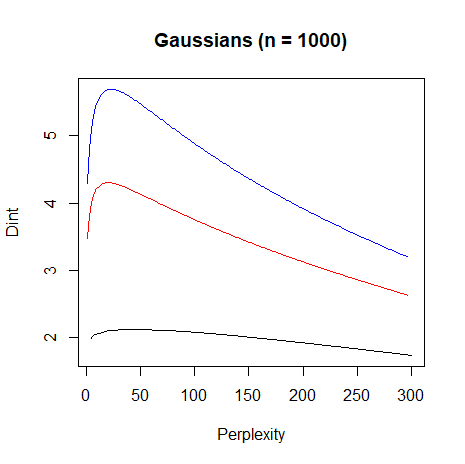

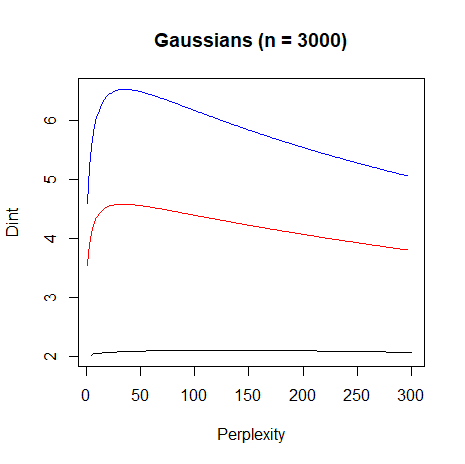

All the curves have the same basic shape (the black curve has the same shape although it’s hard to see): a steep climb at low perplexity to a maximum, followed by a more shallow decrease.

For the 2D Gaussian, the maximum intrinsic dimensionality is `2.12`. For the 5D Gaussian, the maximum intrinsic dimensionality is `4.30`. For the 10D Gaussian, the maximum intrinsic dimensionality is `5.69`, so the estimate of the intrinsic dimensionality becomes an underestimate with increasing dimensionality quite quickly.

With 3000 points, the estimates of the intrinsic dimensionality are `2.10`, `4.58` and `6.53`, respectively. These are all closer to the true dimensionality, but not that much closer.

So even for the simple case of a single Gaussian, the absolute value of the intrinsic dimensionality needs a large number of points to be accurate. But the perplexity that corresponds to the maximum intrinsic dimensionality may be of use.

Does the suggested perplexity that accords to the maximum intrisic dimensionality lead to a useful embedding? Looking at plots of Gaussians is not exactly informative, but [How to Use t-SNE Effectively](http://distill.pub/2016/misread-tsne/) does note that a too-low perplexity can lead to the illusion of clusters in the data, even with Gaussians.

Using their example of a 100-dimension Gaussian with 500 points, the estimated intrinsic dimensionality is 6.8 at a perplexity of 23. Running t-SNE on it:

```
g100d_500 <- snedata::gaussian_data(n = 500, dim = 100, color = "#003399")
g100d_500_pexp <- perp_explore(g100d_500, scale = FALSE)
g100d_500_tsne <- smallvis(g100d_500, Y_init = "spca", scale = FALSE, perplexity = 23)
```

The final result is:

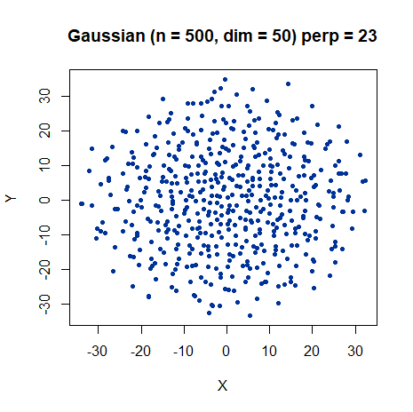

This gives the smooth, fairly uniform distribution of points that the authors identify as being ideal, but which they found by manually tuning the perplexity. They use a perplexity of 30, which is close enough to our choice, seeing as they try perplexities between 5 and 100. A good start for intrinsic dimensionality.

### Ball, Sphere and Helix

The multiscale JSE paper presents data for some other simple synthetic data: a ball, a hollow sphere, and a circular helix:

```
ball <- snedata::ball(n = 1500)
sphere <- snedata::sphere(n = 3000)
helix <- snedata::helix(n = 1500, rmajor = 3, rminor = 1, nwinds = 30)
```

The ball and sphere have an obvious structure. Below on the left is a plot of PCA on the circular helix, which gives a good indication of what it looks like and on the right are the intrinsic dimensionality plots. The ball plot is in black, the sphere plot is in red, and the helix plot is in blue:

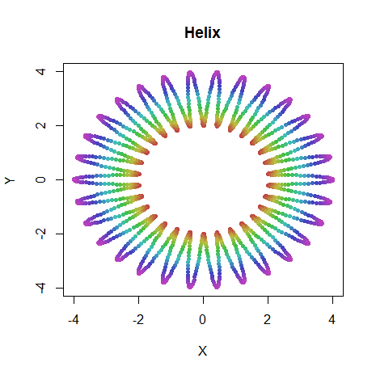

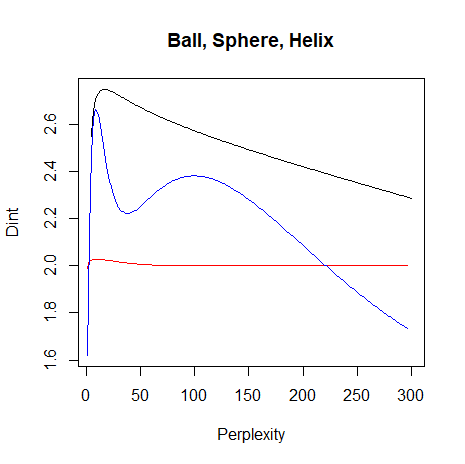

The sphere and ball plot show a similar structure to the Gaussians, with one maximum on each plot. The helix plot shows a more interesting structure: two maxima. Presumably the low perplexity maximum (at perplexity = 13) represents the radius of the helix, and the maximum at the high perplexity (perplexity = 104) is the overall circular structure created by joining the ends of the helices.

Perhaps this can be illuminated by running t-SNE at the different perplexities:

```
smallvis(helix, Y_init = "pca", scale = FALSE, perplexity = 13)
smallvis(helix, Y_init = "pca", scale = FALSE, perplexity = 104)
```

Results are below, the low-perplexity result on the left and the high-perplexity result on the right:

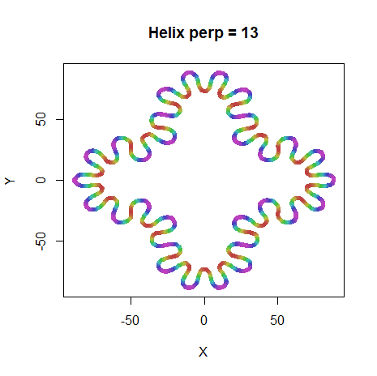

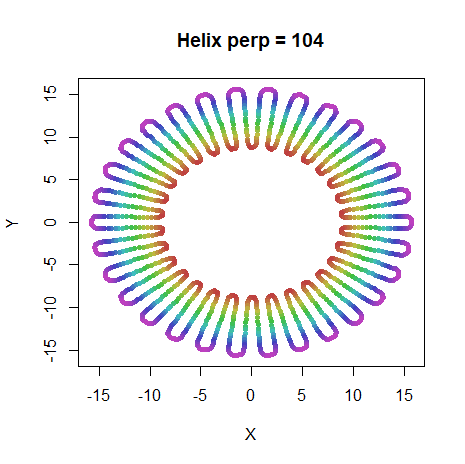

As can be seen, at perplexity 13, the larger circular structure is sacrificed to emphasise the loops of the helix. At higher perplexity, the overall circular structure is maintained.

Here’s a comparison of the intrinsic dimensionalities calculated in `smallvis` and those given in the multiscale JSE paper via the finite difference method (the perplexity at which the maximum occurs is in parentheses):

| Name | msJSE | smallvis |
| --- | --- | --- |
| ball | 2.81 | 2.75 (17) |
| sphere | 2.02 | 2.03 (14) |
| helix | 2.47 | 2.66 (13), 2.38 (104) |

The `ball` and `sphere` results are pretty close. Only one `helix` maximum is reported in the multiscale JSE paper, and it lies between the two values calculated here. I’m not that concerned because the exact values will be affected by the radius of the helix and that of the overall circle, which aren’t given in the paper, so I just estimated them from an image in the paper.

### Swiss Roll

Like `helix`, the Swiss Roll also has two different structures at two scales: the overall curled topology at a large scale and the unfolded two-dimensional sheet that results from small scales.

```
sr3k <- snedata::swiss_roll(n = 3000, max_z = 30)
```

Here’s the intrinsic dimensionality plot:

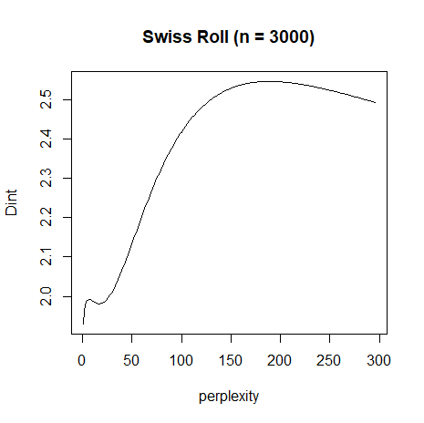

Pleasingly, there are indeed two maxima: a dimensionality of 1.99 at perplexity 11, and a dimensionality of 2.55 at perplexity 193. As it’s pretty fruitless to try and [unfold the Swiss Roll with t-SNE](https://jlmelville.github.io/smallvis/swisssne.html), here are the ASNE results for the two perplexities. Both embeddings were intialized with the Laplacian Eigenmap using the symmetrized ASNE matrix with perplexity = 11, which is already quite unfolded. The maximum number of iterations was set to 5,000, `max_iter = 5000`, to allow the low perplexity result to converge properly. The perplexity 11 result is the left hand result below, and the perplexity 193 result is on the right hand side:

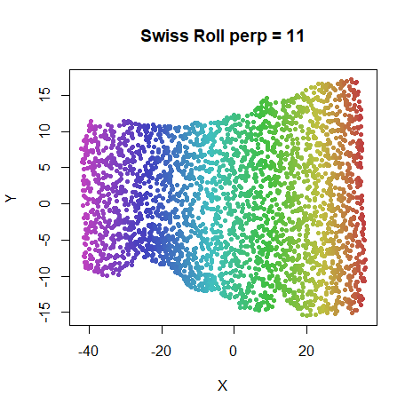

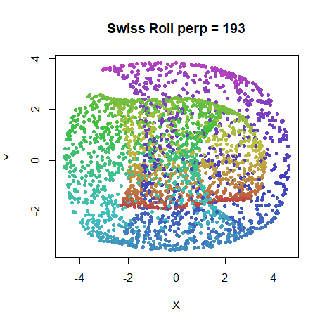

The perplexity 11 result is definitely unfolded, and if it isn’t that even-looking, that’s just par for the course with SNE. The perplexity 193 result, on the other hand, definitely represents the fully folded structure.

### Three Clusters

The three clusters in [How to Use t-SNE Effectively](http://distill.pub/2016/misread-tsne/) exerts a strange fascination for me, as it usefully illustrates the limitations of t-SNE in reproducing the properties of what seems to be a trivial data set. I have gone into [great detail](https://jlmelville.github.io/smallvis/three-clusters.html) on this data previously, but to get started, we just need to know it involves three 50D Gaussians with 50 points each, arranged in a line, with one of the clusters a lot further away from the other two:

```
three_clusters_50 <- snedata::three_clusters_data(n = 50)
```

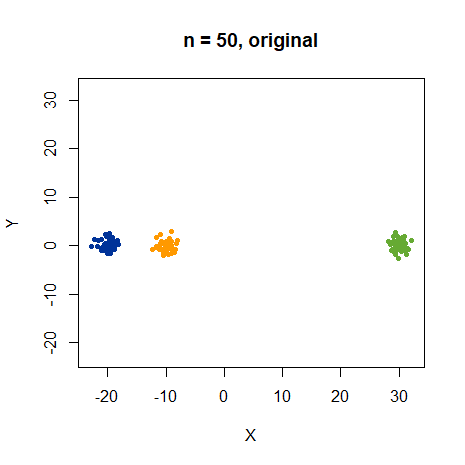

Here’s the intrinsic dimensionality plot:

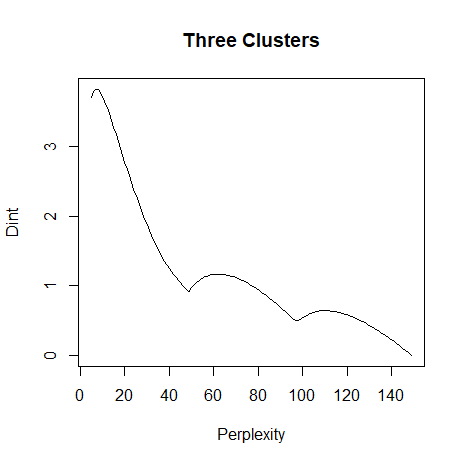

This shows three maxima: at perplexity 7, 62, and 110. These are clearly picking out the existence of three clusters in the data. We’re really going to stack the deck in our favor by initializing from the scaled PCA, which at least starts off with the clusters in a straight line, with the relative distances correct. But do any of these perplexities give the desired result?

```
three_clusters_tsne7 <- smallvis(three_clusters_50, scale = FALSE, Y_init = "spca", perplexity = 7)
```

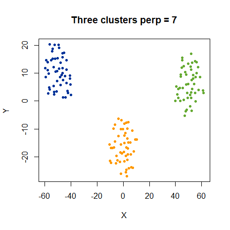

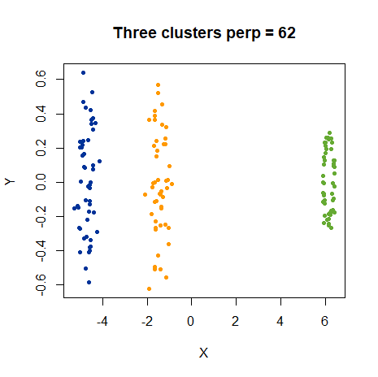

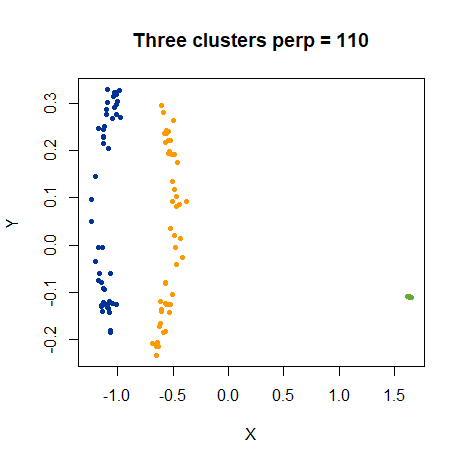

No, they do not. At least the low-perplexity one does a good job of representing the individual clusters: if you look at the axes, you’ll see they are on different scales, which is why the clusters look stretched in the Y-axis. But this is preferable to see more details in the shapes of the clusters at the higher perplexities.

In relation to the three clusters, [How to Use t-SNE Effectively](http://distill.pub/2016/misread-tsne/) notes that there “may not be one perplexity value that will capture distances across all clusters”, but laments that “sadly perplexity is a global parameter”. UNTIL NOW. Surprise! Yes, while I haven’t documented this fact (except here), instead of using a single value, you can provide a vector of perplexities to `smallvis`, one per point in the dataset. I added the feature entirely for this work on intrinsic dimensionality, and it may be entirely useless.

I don’t know if that’s really the problem with the three clusters, but we could look to see if the intrinsic dimensionality is very different when we consider the clusters individually. Rather than plot the mean dimensionality across the whole dataset, we can do so for each cluster separately. Note that the perplexity calculation still uses all 150 points here, but instead of averaging the intrinsic dimensionality at each perplexity for points `1:150`, we averge for `1:50` (the blue cluster), `51:100` (yellow) and `101:150` (green). The per-cluster average dimensionalities are plotted below, with the color of the line matching the clusters. The original per-dataset result is retained, shown in black again (I’ve thickened the per-cluster results to stand out more):

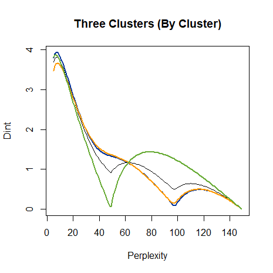

Not much changes at low perplexity. Even the blue and yellow cluster aren’t close enough to perturb each other very much. The yellow cluster values suggest that the optimal perplexity for that cluster is 8, while the other two still suggest a value of 7. So the only change that splitting the intrinsic dimensionality into per-cluster contributions achieves is that for one-third of the dataset only, the perplexity is one higher than it would be otherwise. I won’t show these results, because, as you may be unsurprised to discover, it makes no visible difference to the results.

At least if we take a look at the curves over the entire perplexity range plotted, we can see that the blue and yellow clusters are in a much more similar environment than the green one. This at least roughly accords with what we would expect, although no curve shows unambigious evidence of three clusters. The blue and yellow clusters have a “shoulder” at around perplexity 60 that is the other cluster, with the green cluster providing another maximum at perplexity 120. The green cluster is sufficiently distant from the blue and yellow clusters that they appear as a single broad distribution with a maximum at perplexity of around 80.

Does some combination of these other perplexities, corresponding to other maxima (or even the minima) yield the magical combination of perplexities that produces the “correct” layout? Sadly, the answer is no, but in a way that’s a relief. In more realistic datasets, with overlapping clusters of different sizes, dimensionality and spread, we aren’t likely to see useful structure at higher perplexity anyway.

At this point, I am about ready to throw the towel in on the three clusters and t-SNE, at least from the point of view of reproducing the global structure. I don’t think the problem is due to a global perplexity, anyway. On the bright side, at least the perplexity chosen by the intrinsic dimensionality still shows the Gaussians with nice uniform shapes, even if the relative distances aren’t correct.

### Subset Clusters

Here’s one more example from [How to Use t-SNE Effectively](http://distill.pub/2016/misread-tsne/): two Gaussians, each of 50 dimensions and 75 points each, but one (colored blue) has a standard deviation of 1, and the other (yellow) has a standard deviation of 50. They are both centered at the same point, so the blue cluster is contained entirely within the yellow one. Here’s a PCA plot which shows the situation:

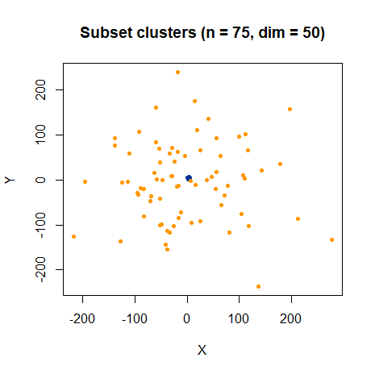

```
subset_clusters <- snedata::subset_clusters_data(n = 75, dim = 50)
```

and here’s the dimensionality plot:

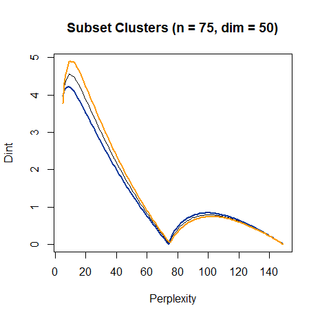

Note that for this dataset, because of the distribution of distances, numerical issues prevent the perplexity calibration succeeding for a small number of points at low perplexities (perplexity 14 and below). When this happens, the k-nearest neighbors get a weight of 1 each, and the intrinsic dimensionality is set to 0. As a result, for this dataset, the dimensionalities in the interesting region may be subject to a small amount of uncertainty.

With that in mind, despite the difference in spread of the clusters, the perplexities for the two clusters are very similar: 8 for the blue cluster and 9 for the yellow cluster. So once again we could just stick with a global perplexity based on the mean of the entire dataset, which would be 8.

Here’s the result for t-SNE using 8 for the blue cluster and 9 for the yellow cluster:

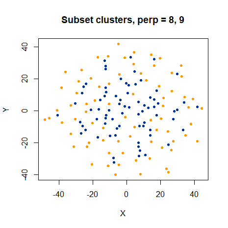

As noted in [How to Use t-SNE Effectively](http://distill.pub/2016/misread-tsne/), the smaller blue cluster has its size hugely expanded. But the chosen perplexity at least avoids the ring shape that forms at large perplexities, so once again we intrinsic dimensionality chooses a “sensible” value.

Overall, using the perplexity that corresponds to first maximum in mean intrinsic dimensionality does a good job with the simple synthetic data used here. There doesn’t seem to be any pressing reason to consider different perplexities with any of these datasets. Perhaps we will find a reason to do so with real datasets?

## Real Datasets

We’ll now look at how perplexity and intrinsic dimensionality are related with the usual [datasets](https://jlmelville.github.io/smallvis/datasets.html). We shall also look at splitting the contributions into clusters. For nearly all the datasets, we are already coloring the plots by a suitable categorical value so we’ll use that to separate out the contributions. The one exception is the `frey` faces, which aren’t categorized, so we won’t use that approach on that dataset.

Separating out the contributions using a pre-existing class label feels like “cheating” anyway, so I’m not suggesting this as a practical approach. Given how time-consuming it is to generate so many perplexity results, it’s already not a practical, so we won’t worry too mych. This is just to see if there’s any evidence that these datasets have any indication of different dimensionalities in different subsets of the data and if so, whether using multiple perplexity values has any obvious effect on the plots.

Where we are splitting the dimensionality plots into different curves based on category, the color of the curve will be the same as that used in the t-SNE plot (`rainbow` colors). The plot of the overall dataset will be in black (and a slightly thinner line). For plots with a large number of classes (e.g. `oli` and `coil20`), the whole-dataset curve will be shown on its own plot.

The [multi-scale JSE paper](https://dx.doi.org/10.1016/j.neucom.2014.12.095) also looked at the `coil20` and `frey` datasets and a subset of `mnist`, in their case a 3,000 item subset. We’ll compare our intrinsic dimensionality estimates with theirs when we hit those datasets.

### Settings

For this section, using the data from the perplexity plot will give us a global perplexity and a per-category perplexity (except in the case of `frey` which doesn’t partition its data into categories). This will lead to two t-SNE plots: one using the global perplexity and one with one perplexity for each point, where the point gets the perplexity associated with its category. Apart from that, we’ll use standard settings for most of the t-SNE experiments in these pages, and in particular those from our previous investigation into [perplexity](https://jlmelville.github.io/smallvis/perplexity.html), except we’ll only use the standard 1,000 iterations. The plots on that page provide a good set of references for what we should expect, where perplexities between 25-50 seem fine for every dataset. Low perplexity (e.g. 5) seemed too low, and required larger number of iterations, without creating any exciting new features in the visualizations.

```
# An example

iris_tsne <- smallvis(iris, scale = "absmax", perplexity = 5, Y_init = "spca",
eta = 100, exaggeration_factor = 4, stop_lying_iter = 50, max_iter = 1000, epoch = 100)
```

### iris

Here’s the dimensionality plot for `iris`:

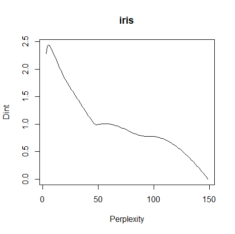

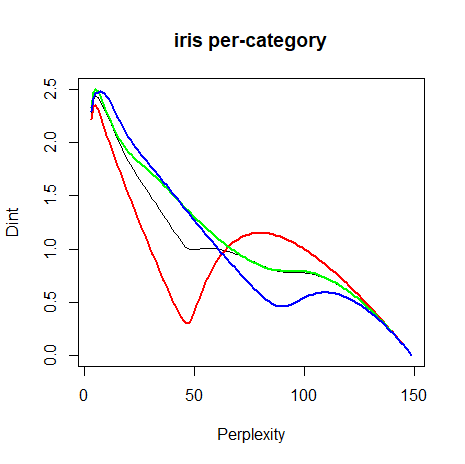

The overall shape of the curves is *very* reminiscent of the synthetic three-clusters dataset we looked at above. The suggested perplexity is 5 for the dataset as a whole, and when broken out by `Species`, the perplexity is still suggested to be 5 for `setosa` and `versicolor`, but a whopping 7 for `virginica`. We already know that we’re not going to love the results, but here they are:

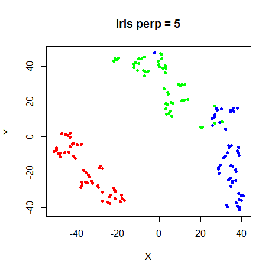

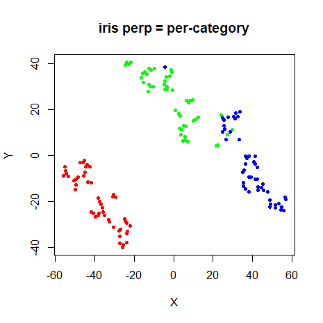

Perhaps this indicates that for small datasets, the perplexity tends to be under-estimated? We could just give up now. But we won’t. Still so many other ways for us to be disappointed! Also, in my hands, the [pBIC](https://arxiv.org/abs/1708.03229) was awfully fond of suggesting a perplexity of 5 as the optimal result for these datasets (see the [perplexity](https://jlmelville.github.io/smallvis/perplexity.html) page for more details), so I’m in good company.

### s1k

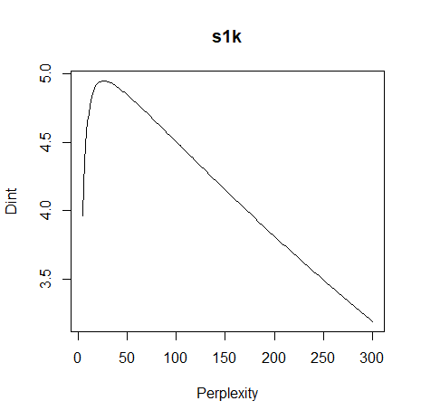

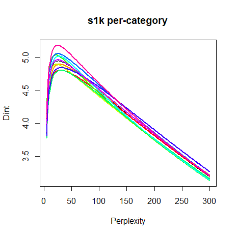

I didn’t expect to see much difference between the 10 clusters in `s1k`: they are pretty much identical in terms of composition, spread and relative distance. So it’s not to suprising that their dimensionality curves are quite similar. The recommended global perplexity for this dataset is `26`, while the per-cluster perplexities range from `22` to `31`.

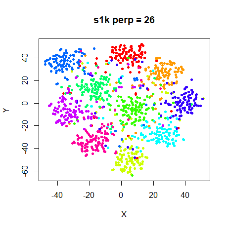

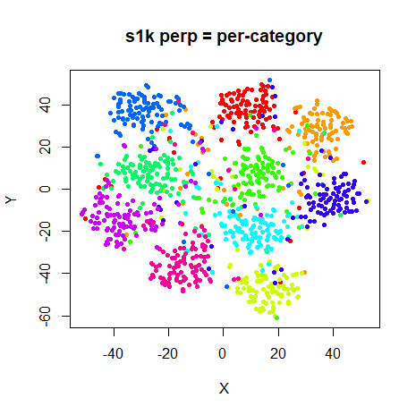

Big improvement over the results for `iris`, I think. I can’t see a big reason to want to use the per-category visualization over the global perplexty and a method that suggests a perplexity between 20-30 is not that Earth-shaking a revelation, but at least it didn’t suggest a perplexity of 5. My confidence has returned somewhat.

### oli

The Olivetti faces contain 40 different classes. There’s no good way to show 40 different curves, so let’s just take a deep breath and get through this together:

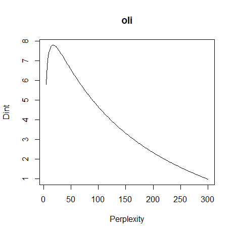

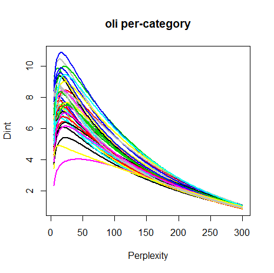

I won’t be getting a Christmas card from the Society for Intelligible Images for this one. But there is a bit of an indication that the different sets of faces show different dimensionalities: compare the bottom three curves (in purple, yellow and black) with the top blue curve for example. And intriguingly there is an interesting spread of perplexities: between 11-22, except for face number 22, where a perplexity of 42 is suggested. The average over the entire dataset is 17.

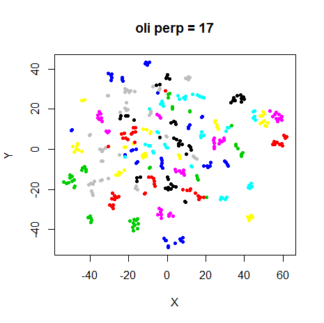

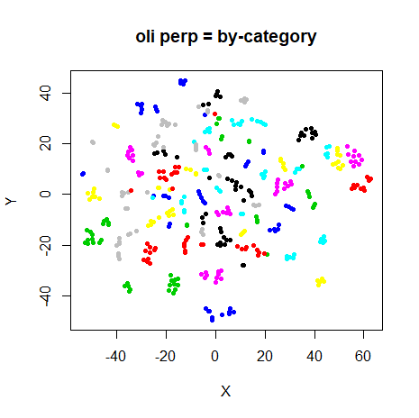

The perplexity = 17 result gives a perfectly good visualization. And so does the per-category result, to the extent that it’s quite hard to spot any meaningful differences between the two.